# Homework 1/ Scatter Plots with ggplot2 package

Tesfahun Tegene Boshe

04/11/2021

## Instructions

- Find interesting dataset and prepare short report (in R Markdown) which will consist:
- short description of the dataset,
- 3 scatterplots which will present interesting relationships between variables,
- brief comments which describes obtained results.

## Necessary packages

```r
# # install the libraries
# install.packages('ggplot2')
# install.packages('dplyr')
# install.packages('tidyr')
# install.packages('carData')

# load the libraries
library(ggplot2)
library(dplyr)
library(tidyr)
library(carData) # source for the data
```

## Dataset

For this task, Salaries dataset,The 2008-09 nine-month academic salary for Assistant Professors, Associate Professors and Professors in a college in the U.S will be used. The data were collected as part of the on-going effort of the college’s administration to monitor salary differences between male and female faculty members.

*Variable* | *Description*

- rank | a factor with levels AssocProf AsstProf Prof
- discipline | a factor with levels A (“theoretical” departments) or B (“applied” departments).
- yrs.since.phd | years since PhD.
- yrs.service | years of service.
- sex | a factor with levels Female Male
- salary | nine-month salary, in dollars.

```r
data(Salary)
```

## plots

### Plot 1. Salary vs years of service for each sex

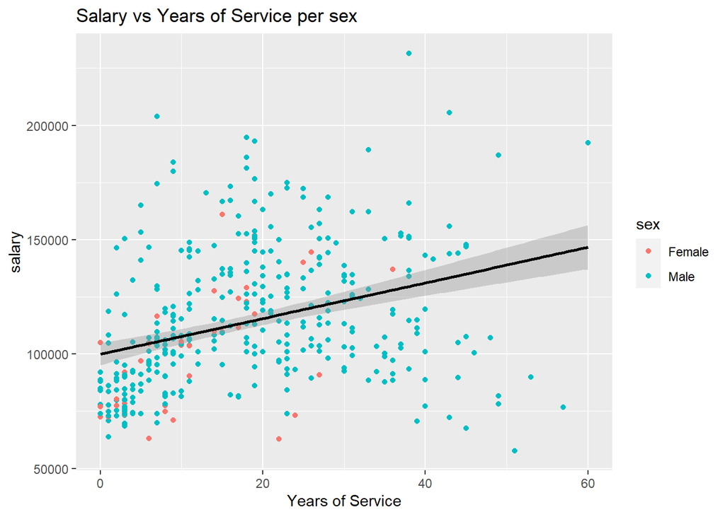

```r
ggplot(data=Salaries, aes(x=yrs.service,y = salary, color=sex))+
  geom_point() +
  labs(x = "Years of Service")+
  ggtitle("Salary vs Years of Service per sex") +
  geom_smooth(method = "lm", color = "black")
```

comments:

- majority of the female professors are paid less than the market average
- there is a positive correlation between years of service and salary variables.
- this is with the exception to the age group 40-60 years of service, where there is a general decrease in salary
- with years of experience

### Plot 2.1 Salary vs years since PHD for each rank

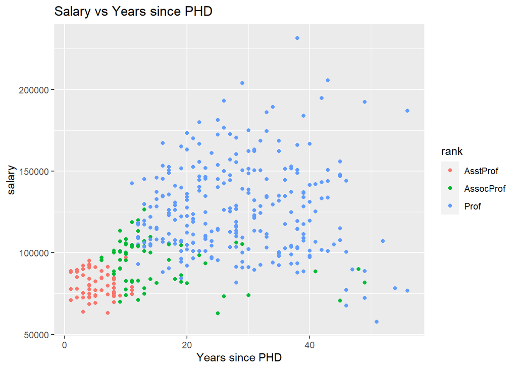

```r
ggplot(data=Salaries, aes(x=yrs.since.phd,y = salary, color=rank))+
  geom_point() +
  labs(x = "Years since PHD")+
  ggtitle("Salary vs Years since PHD")
```

### Plot 2.2 Salary vs years since PHD for each discipline

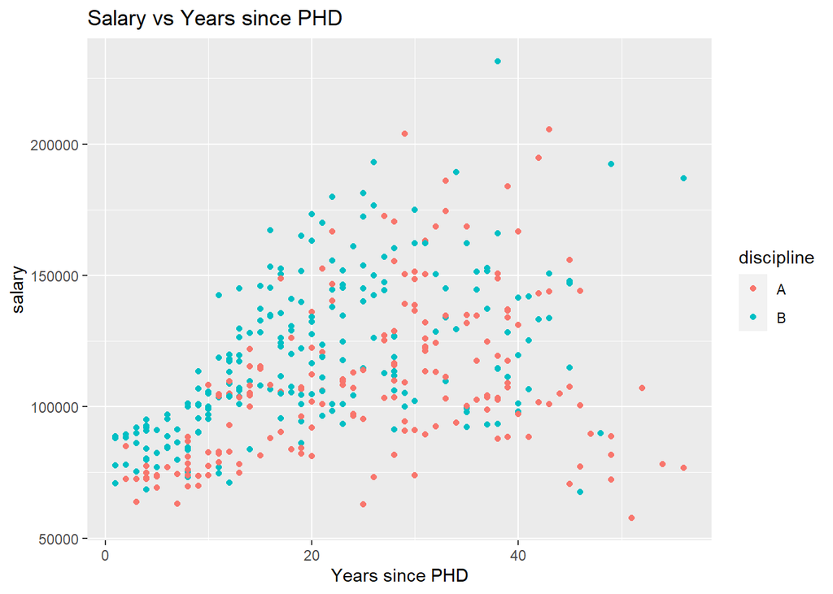

```r
ggplot(data=Salaries, aes(x=yrs.since.phd,y = salary, color=discipline))+
  geom_point() +
  labs(x = "Years since PHD")+
  ggtitle("Salary vs Years since PHD")
```

Comments:

- applied departments pay more than theoretical departments

### plot 2.3 Salary vs years since PHD for each rank X discipline

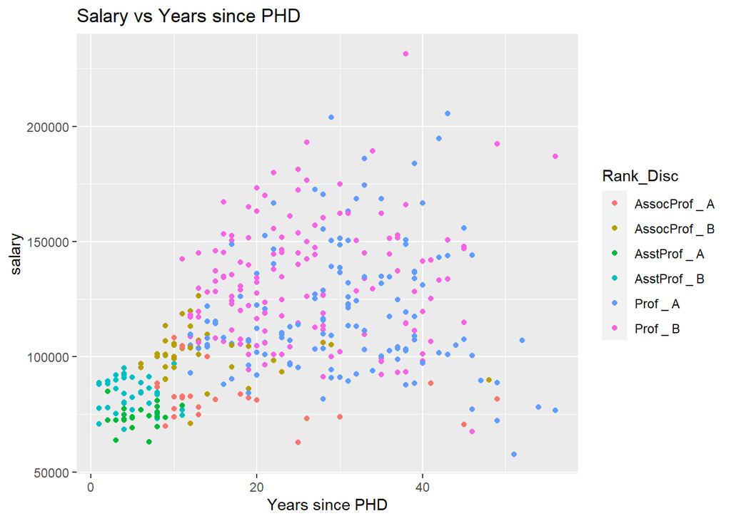

```r
Salaries$Rank_Disc <- paste(Salaries$rank,"_", Salaries$discipline)
# a new variable Rank_Disc is a cross product of rank and discipline

ggplot(data=Salaries, aes(x=yrs.since.phd,y = salary, color=Rank_Disc))+
  geom_point() +
  labs(x = "Years since PHD")+
  ggtitle("Salary vs Years since PHD")
```

Comments:

- Professors in applied departments are of the highest market value
- The properties in 2.1 and 2.2 are observed here too.

### Plot 3. Bar plot of counts of individuals per sex per discipline

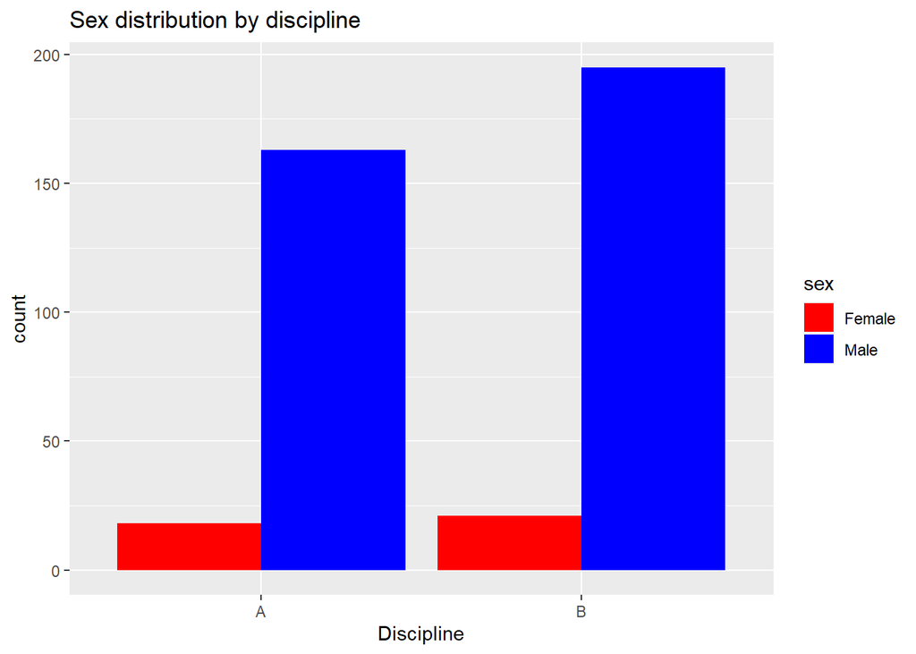

```r
ggplot(data=Salaries, aes(x=discipline, fill=sex))+
  geom_bar(stat="count", position="dodge") + #add position="dodge" to geom_bar to have the groups next to each other
  labs(x = "Discipline")+
  ggtitle("Sex distribution by discipline") +
  scale_fill_manual(values=c("red", "blue"))
```